# Arboles de Desición

Erick Marroquín

2026-03-13

# Introducción

Este documento analiza el famoso dataset del Titanic para construir un modelo de árbol de decisión que prediga si un pasajero sobrevivió o no al hundimiento del barco el 15 de abril de 1912.

El objetivo pedagógico es recorrer el flujo completo de un análisis de aprendizaje supervisado:

1. Descripción del problema y las variables.
2. Análisis exploratorio de datos (EDA).
3. Preprocesamiento.
4. Ingeniería de variables (Feature Engineering).
5. Entrenamiento de un modelo base.
6. Evaluación del modelo.
7. Ajuste de hiperparámetros (tuning) con validación cruzada.
8. Random Forest.
9. Comparación de resultados.

# Paquetes necesarios

```r
# Instalación (solo la primera vez — descomentá si es necesario):
# install.packages(c("tidyverse", "rpart", "rpart.plot", "caret", "Hmisc", "ranger"))

# tidyverse: colección de paquetes para manipulación y visualización de datos.
library(tidyverse)

# rpart: implementación de árboles de decisión (Recursive PARTitioning).
library(rpart)

# rpart.plot: visualización mejorada de árboles rpart.
library(rpart.plot)

# caret: framework para entrenamiento, tuning y validación de modelos.
library(caret)

# Hmisc: herramientas útiles para describir y explorar datos.
library(Hmisc)

# ranger: implementación rápida de Random Forest con más hiperparámetros.
library(ranger)
```

# Carga de datos

```r
# Leer el archivo CSV descargado desde Kaggle.
# Asegurate de que el archivo "Titanic-Dataset.csv" esté en el mismo
# directorio que este .Rmd, o ajusta la ruta según corresponda.
titanic <- read.csv("Titanic-Dataset.csv", stringsAsFactors = FALSE)

# Verificar las dimensiones: filas (pasajeros) y columnas (variables).
cat("Filas:", nrow(titanic), "\n")
```

```
## Filas: 891
```

```r
cat("Columnas:", ncol(titanic), "\n")
```

```
## Columnas: 12
```

```r
# Ver las primeras 6 filas para tener una primera impresión del dataset.
head(titanic)
```

```
##   PassengerId Survived Pclass
## 1           1        0      3
## 2           2        1      1
## 3           3        1      3
## 4           4        1      1
## 5           5        0      3
## 6           6        0      3
##                                                  Name    Sex Age SibSp Parch
## 1                             Braund, Mr. Owen Harris   male  22     1     0
## 2 Cumings, Mrs. John Bradley (Florence Briggs Thayer) female  38     1     0
## 3                              Heikkinen, Miss. Laina female  26     0     0
## 4        Futrelle, Mrs. Jacques Heath (Lily May Peel) female  35     1     0
## 5                            Allen, Mr. William Henry   male  35     0     0
## 6                                    Moran, Mr. James   male  NA     0     0
##             Ticket    Fare Cabin Embarked
## 1        A/5 21171  7.2500              S
## 2         PC 17599 71.2833   C85        C
## 3 STON/O2. 3101282  7.9250              S
## 4           113803 53.1000  C123        S
## 5           373450  8.0500              S
## 6           330877  8.4583              Q
```

# Descripción de variables

El dataset contiene información sobre 891 pasajeros del Titanic. A continuación se describe cada variable:

Descripción de variables del dataset Titanic

| Variable | Tipo | Descripcion |
| --- | --- | --- |
| PassengerId | Entero | Identificador único del pasajero |
| Survived | Entero (0/1) | Variable objetivo: 1 = Sobrevivió, 0 = No sobrevivió |
| Pclass | Entero (1/2/3) | Clase del ticket: 1ª (alta), 2ª (media), 3ª (baja) |
| Name | Texto | Nombre completo del pasajero |
| Sex | Texto | Sexo: male / female |
| Age | Numérico | Edad en años |
| SibSp | Entero | Número de hermanos/cónyuge a bordo |
| Parch | Entero | Número de padres/hijos a bordo |
| Ticket | Texto | Número de ticket |
| Fare | Numérico | Tarifa pagada (en libras esterlinas) |
| Cabin | Texto | Número de camarote |
| Embarked | Texto | Puerto de embarque: C=Cherburgo, Q=Queenstown, S=Southampton |

> **Variable objetivo:** `Survived` — lo que el modelo debe aprender a predecir.

# Análisis Exploratorio de Datos (EDA)

## Resumen estadístico

```r
# summary() muestra estadísticas básicas para cada variable:
# mínimo, máximo, media, mediana, y conteo de valores NA.
summary(titanic)
```

```
##   PassengerId       Survived          Pclass          Name
##  Min.   :  1.0   Min.   :0.0000   Min.   :1.000   Length:891
##  1st Qu.:223.5   1st Qu.:0.0000   1st Qu.:2.000   Class :character
##  Median :446.0   Median :0.0000   Median :3.000   Mode  :character
##  Mean   :446.0   Mean   :0.3838   Mean   :2.309
##  3rd Qu.:668.5   3rd Qu.:1.0000   3rd Qu.:3.000
##  Max.   :891.0   Max.   :1.0000   Max.   :3.000
##
##      Sex                 Age            SibSp           Parch
##  Length:891         Min.   : 0.42   Min.   :0.000   Min.   :0.0000
##  Class :character   1st Qu.:20.12   1st Qu.:0.000   1st Qu.:0.0000
##  Mode  :character   Median :28.00   Median :0.000   Median :0.0000
##                     Mean   :29.70   Mean   :0.523   Mean   :0.3816
##                     3rd Qu.:38.00   3rd Qu.:1.000   3rd Qu.:0.0000
##                     Max.   :80.00   Max.   :8.000   Max.   :6.0000
##                     NA's   :177
##     Ticket               Fare           Cabin             Embarked
##  Length:891         Min.   :  0.00   Length:891         Length:891
##  Class :character   1st Qu.:  7.91   Class :character   Class :character
##  Mode  :character   Median : 14.45   Mode  :character   Mode  :character
##                     Mean   : 32.20
##                     3rd Qu.: 31.00
##                     Max.   :512.33
##
```

## Valores faltantes

```r
# Contar cuántos NA tiene cada columna.
na_por_columna <- colSums(is.na(titanic))

# Mostrar solo las columnas que tienen al menos 1 NA.
na_por_columna[na_por_columna > 0]
```

```
## Age
## 177
```

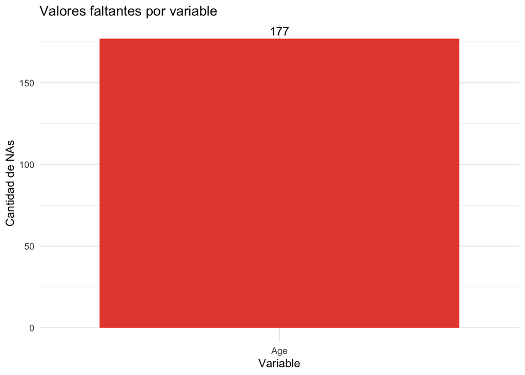

```r
na_df <- data.frame(
  variable  = names(na_por_columna),
  faltantes = as.integer(na_por_columna)
) %>%
  filter(faltantes > 0)

ggplot(na_df, aes(x = reorder(variable, -faltantes), y = faltantes)) +
  geom_col(fill = "#e74c3c") +
  geom_text(aes(label = faltantes), vjust = -0.4, size = 4) +
  labs(
    title = "Valores faltantes por variable",
    x = "Variable",
    y = "Cantidad de NAs"
  ) +
  theme_minimal()
```

## Distribución de la variable objetivo

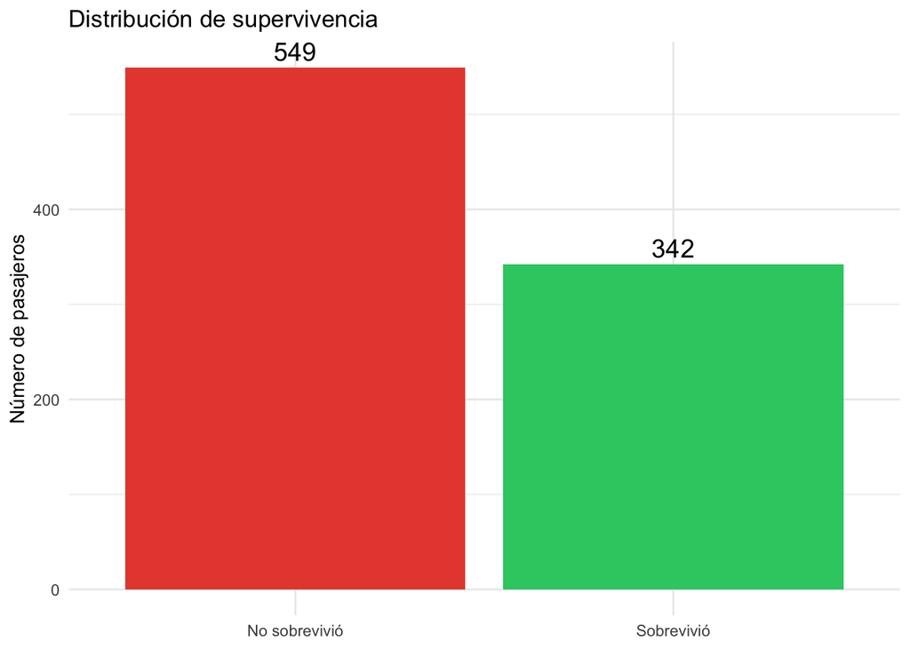

```r
titanic %>%
  mutate(Survived = factor(Survived, labels = c("No sobrevivió", "Sobrevivió"))) %>%
  ggplot(aes(x = Survived, fill = Survived)) +
  geom_bar() +
  geom_text(stat = "count", aes(label = ..count..), vjust = -0.4, size = 5) +
  scale_fill_manual(values = c("#e74c3c", "#2ecc71")) +
  labs(
    title = "Distribución de supervivencia",
    x = NULL,
    y = "Número de pasajeros"
  ) +
  theme_minimal() +
  theme(legend.position = "none")
```

> El dataset está desbalanceado: murieron más pasajeros de los que sobrevivieron. Esto es importante al interpretar la precisión del modelo.

## Supervivencia por sexo

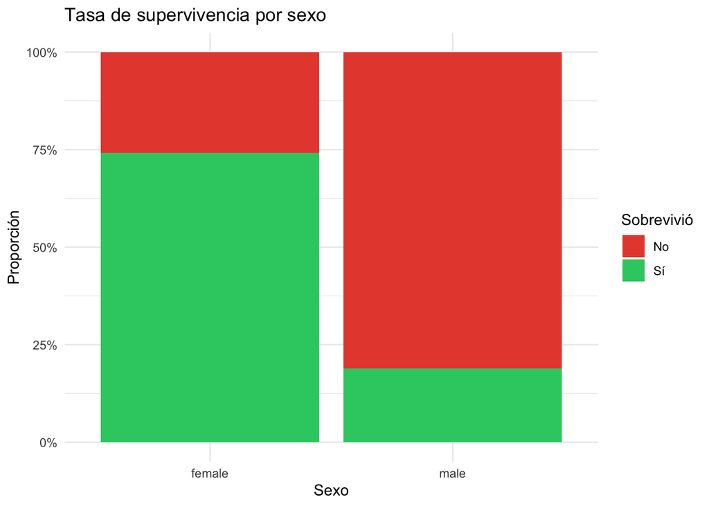

```r
titanic %>%
  mutate(Survived = factor(Survived, labels = c("No", "Sí"))) %>%
  ggplot(aes(x = Sex, fill = Survived)) +
  geom_bar(position = "fill") +
  scale_y_continuous(labels = scales::percent) +
  scale_fill_manual(values = c("#e74c3c", "#2ecc71")) +
  labs(
    title = "Tasa de supervivencia por sexo",
    x = "Sexo",
    y = "Proporción",
    fill = "Sobrevivió"
  ) +
  theme_minimal()
```

## Supervivencia por clase de ticket

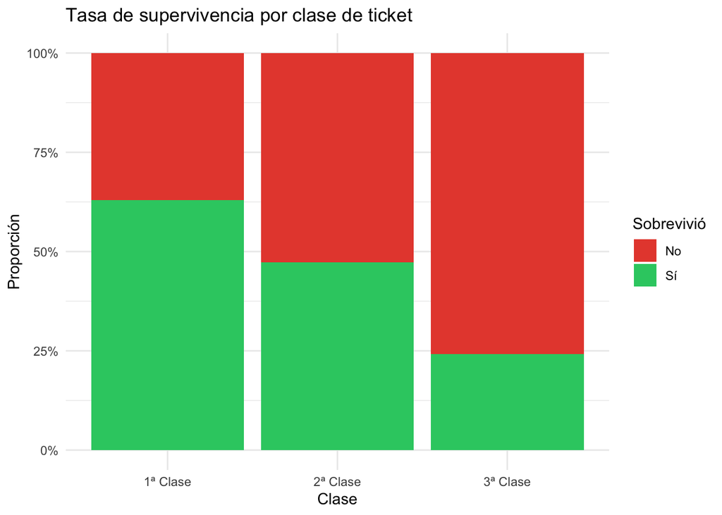

```r
titanic %>%
  mutate(
    Survived = factor(Survived, labels = c("No", "Sí")),
    Pclass   = factor(Pclass, labels = c("1ª Clase", "2ª Clase", "3ª Clase"))
  ) %>%
  ggplot(aes(x = Pclass, fill = Survived)) +
  geom_bar(position = "fill") +
  scale_y_continuous(labels = scales::percent) +
  scale_fill_manual(values = c("#e74c3c", "#2ecc71")) +
  labs(
    title = "Tasa de supervivencia por clase de ticket",
    x = "Clase",
    y = "Proporción",
    fill = "Sobrevivió"
  ) +
  theme_minimal()
```

## Distribución de edad

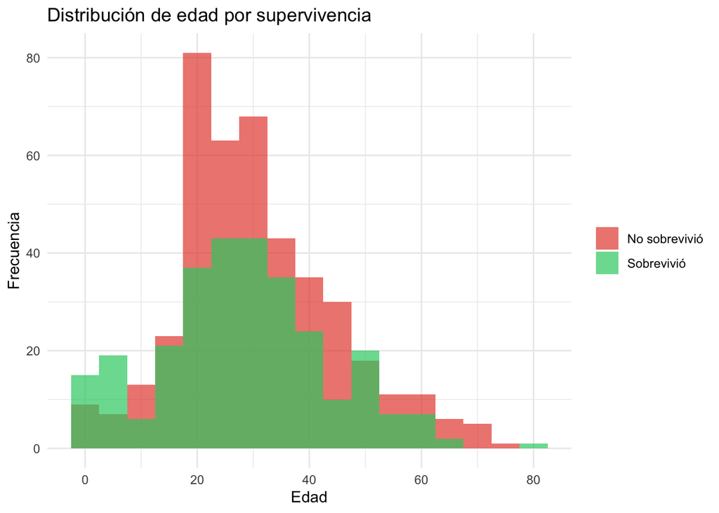

```r
titanic %>%
  filter(!is.na(Age)) %>%
  mutate(Survived = factor(Survived, labels = c("No sobrevivió", "Sobrevivió"))) %>%
  ggplot(aes(x = Age, fill = Survived)) +
  geom_histogram(binwidth = 5, alpha = 0.7, position = "identity") +
  scale_fill_manual(values = c("#e74c3c", "#2ecc71")) +
  labs(
    title = "Distribución de edad por supervivencia",
    x = "Edad",
    y = "Frecuencia",
    fill = NULL
  ) +
  theme_minimal()
```

## Tarifa pagada por clase

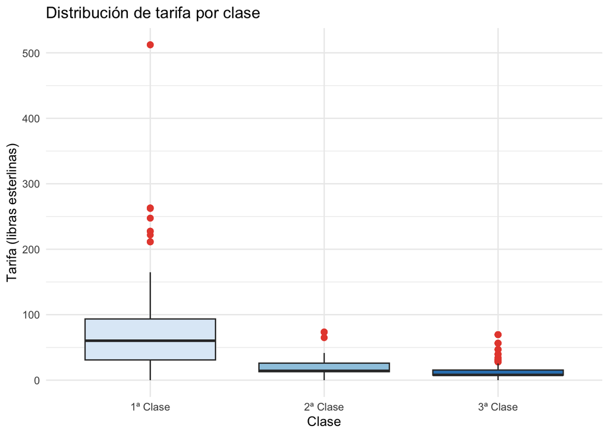

```r
titanic %>%
  mutate(Pclass = factor(Pclass, labels = c("1ª Clase", "2ª Clase", "3ª Clase"))) %>%
  ggplot(aes(x = Pclass, y = Fare, fill = Pclass)) +
  geom_boxplot(outlier.colour = "#e74c3c", outlier.size = 2) +
  scale_fill_brewer(palette = "Blues") +
  labs(
    title = "Distribución de tarifa por clase",
    x = "Clase",
    y = "Tarifa (libras esterlinas)"
  ) +
  theme_minimal() +
  theme(legend.position = "none")
```

# Preprocesamiento

## Selección de variables

```r
# Conservamos Name porque extraeremos el título.
# Conservamos Age porque crearemos una variable categórica a partir de ella.
titanic_clean <- titanic %>%
  select(Survived, Pclass, Sex, Age, SibSp, Parch, Fare, Embarked, Name)

cat("Variables seleccionadas:", ncol(titanic_clean), "\n")
```

```
## Variables seleccionadas: 9
```

## Imputación de valores faltantes

```r
# Age: imputar los NA con la mediana.
mediana_edad <- median(titanic_clean$Age, na.rm = TRUE)
titanic_clean$Age[is.na(titanic_clean$Age)] <- mediana_edad

cat("Mediana de edad usada para imputación:", mediana_edad, "\n")
```

```
## Mediana de edad usada para imputación: 28
```

```r
# Embarked: imputar con la moda.
moda_embarked <- names(sort(table(titanic_clean$Embarked), decreasing = TRUE))[1]
titanic_clean$Embarked[titanic_clean$Embarked == ""] <- moda_embarked

cat("Moda de Embarked usada para imputación:", moda_embarked, "\n")
```

```
## Moda de Embarked usada para imputación: S
```

```r
cat("NAs restantes:", sum(is.na(titanic_clean)), "\n")
```

```
## NAs restantes: 0
```

# Ingeniería de Variables (Feature Engineering)

El preprocesamiento limpia los datos tal como están. La ingeniería de variables va un paso más allá: **crea nuevas variables** que el modelo no podría descubrir por sí solo a partir de los datos en bruto.

## Extracción del título

Los nombres tienen el formato `Apellido, Título. Nombre`. El título (`Mr.`, `Mrs.`, `Miss.`, `Master.`) concentra en una sola palabra información sobre sexo, edad aproximada y clase social.

```r
titanic_clean <- titanic_clean %>%
  mutate(
    Title = str_extract(Name, ",\\s([A-Za-z]+)\\."),
    Title = str_remove_all(Title, ",\\s|\\."),
    Title = str_trim(Title)
  )

table(titanic_clean$Title)
```

```
##
##     Capt      Col      Don       Dr Jonkheer     Lady    Major   Master
##        1        2        1        7        1        1        2       40
##     Miss     Mlle      Mme       Mr      Mrs       Ms      Rev      Sir
##      182        2        1      517      125        1        6        1
```

```r
# Títulos raros se consolidan en "Rare" para evitar ruido.
titanic_clean <- titanic_clean %>%
  mutate(
    Title = case_when(
      Title %in% c("Mr")                                           ~ "Mr",
      Title %in% c("Miss", "Mlle", "Ms")                          ~ "Miss",
      Title %in% c("Mrs", "Mme")                                  ~ "Mrs",
      Title %in% c("Master")                                      ~ "Master",
      Title %in% c("Dr", "Rev", "Col", "Major", "Capt",
                   "Sir", "Jonkheer", "Don", "Lady", "Countess")  ~ "Rare",
      TRUE                                                         ~ "Other"
    )
  )

cat("Títulos finales:\n")
```

```
## Títulos finales:
```

```r
table(titanic_clean$Title)
```

```
##
## Master   Miss     Mr    Mrs  Other   Rare
##     40    185    517    126      1     22
```

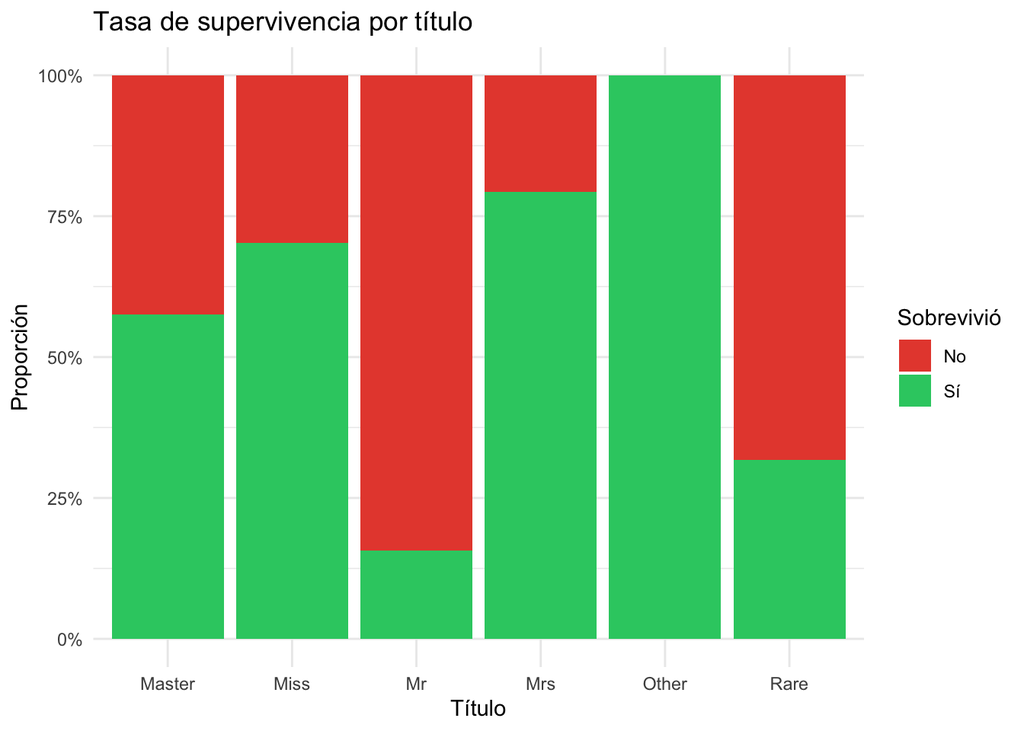

```r
titanic_clean %>%
  mutate(Survived = factor(Survived, labels = c("No", "Sí"))) %>%
  ggplot(aes(x = Title, fill = Survived)) +
  geom_bar(position = "fill") +
  scale_y_continuous(labels = scales::percent) +
  scale_fill_manual(values = c("#e74c3c", "#2ecc71")) +
  labs(
    title = "Tasa de supervivencia por título",
    x = "Título",
    y = "Proporción",
    fill = "Sobrevivió"
  ) +
  theme_minimal()
```

## Categorización de edad (AgeBin)

La edad continua, especialmente después de imputación por mediana, pierde información importante. Los niños menores de 12 años tuvieron prioridad en los botes salvavidas — ese patrón se diluye con un valor numérico. Convertir la edad a categorías preserva esa señal de forma explícita.

```r
# Dividir la edad en 5 categorías con significado real en el contexto del Titanic.
titanic_clean <- titanic_clean %>%
  mutate(
    AgeBin = case_when(
      Age < 12              ~ "Niño",
      Age >= 12 & Age < 18  ~ "Adolescente",
      Age >= 18 & Age < 35  ~ "Adulto joven",
      Age >= 35 & Age < 60  ~ "Adulto",
      Age >= 60             ~ "Mayor"
    ),
    AgeBin = factor(AgeBin,
                    levels = c("Niño", "Adolescente",
                               "Adulto joven", "Adulto", "Mayor"))
  )

cat("Distribución de AgeBin:\n")
```

```
## Distribución de AgeBin:
```

```r
table(titanic_clean$AgeBin)
```

```
##
##         Niño  Adolescente Adulto joven       Adulto        Mayor
##           68           45          543          209           26
```

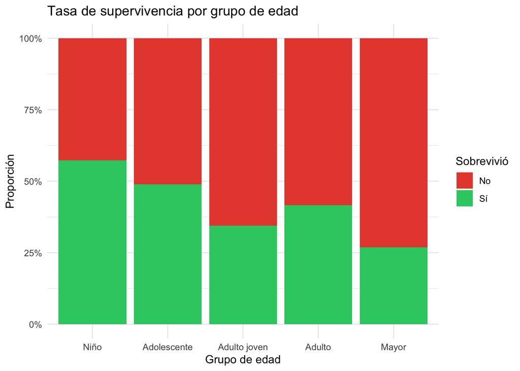

```r
titanic_clean %>%
  mutate(Survived = factor(Survived, labels = c("No", "Sí"))) %>%
  ggplot(aes(x = AgeBin, fill = Survived)) +
  geom_bar(position = "fill") +
  scale_y_continuous(labels = scales::percent) +
  scale_fill_manual(values = c("#e74c3c", "#2ecc71")) +
  labs(
    title = "Tasa de supervivencia por grupo de edad",
    x = "Grupo de edad",
    y = "Proporción",
    fill = "Sobrevivió"
  ) +
  theme_minimal()
```

## Tamaño de familia e indicador de viaje solo

```r
titanic_clean <- titanic_clean %>%
  mutate(
    FamilySize = SibSp + Parch + 1,
    IsAlone    = if_else(FamilySize == 1, 1, 0)
  )

cat("Distribución de tamaño de familia:\n")
```

```
## Distribución de tamaño de familia:
```

```r
table(titanic_clean$FamilySize)
```

```
##
##   1   2   3   4   5   6   7   8  11
## 537 161 102  29  15  22  12   6   7
```

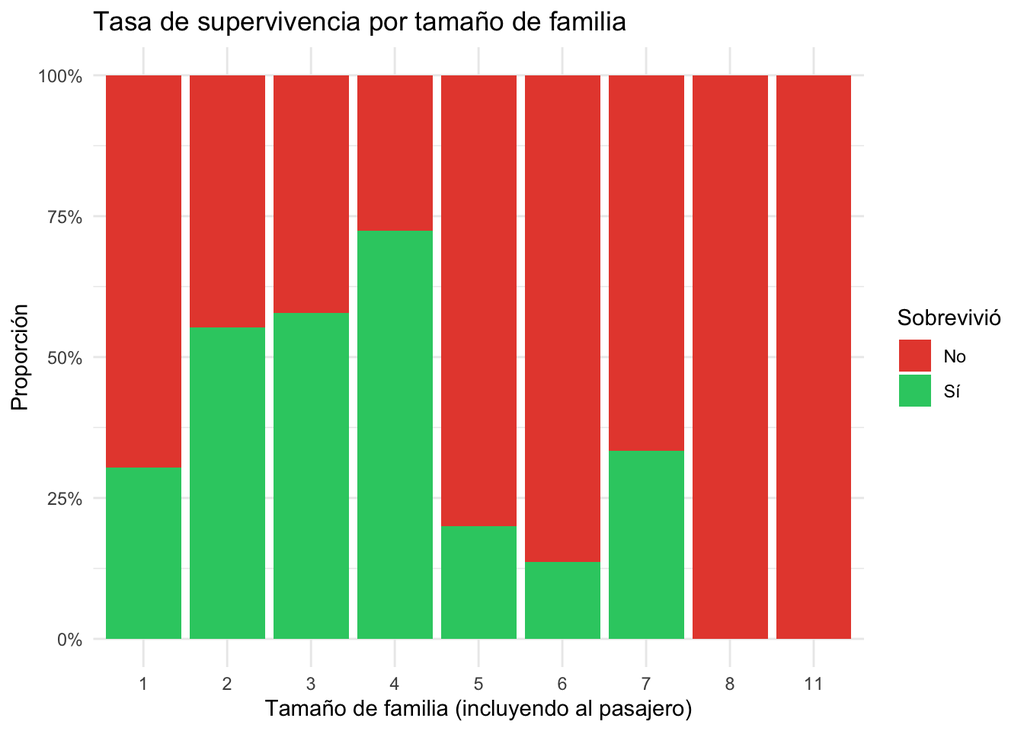

```r
titanic_clean %>%
  mutate(Survived = factor(Survived, labels = c("No", "Sí"))) %>%
  ggplot(aes(x = factor(FamilySize), fill = Survived)) +
  geom_bar(position = "fill") +
  scale_y_continuous(labels = scales::percent) +
  scale_fill_manual(values = c("#e74c3c", "#2ecc71")) +
  labs(
    title = "Tasa de supervivencia por tamaño de familia",
    x = "Tamaño de familia (incluyendo al pasajero)",
    y = "Proporción",
    fill = "Sobrevivió"
  ) +
  theme_minimal()
```

## Dataset final para modelado

```r
# Descartamos: Name (título ya extraído), SibSp y Parch (absorbidos en FamilySize),
# Age continua (reemplazada por AgeBin), Fare (redundante con Pclass).
titanic_model <- titanic_clean %>%
  select(Survived, Pclass, Sex, AgeBin, Embarked,
         Title, FamilySize, IsAlone)

cat("Variables finales para el modelo:\n")
```

```
## Variables finales para el modelo:
```

```r
str(titanic_model)
```

```
## 'data.frame':    891 obs. of  8 variables:
##  $ Survived  : int  0 1 1 1 0 0 0 0 1 1 ...
##  $ Pclass    : int  3 1 3 1 3 3 1 3 3 2 ...
##  $ Sex       : chr  "male" "female" "female" "female" ...
##  $ AgeBin    : Factor w/ 5 levels "Niño","Adolescente",..: 3 4 3 4 4 3 4 1 3 2 ...
##  $ Embarked  : chr  "S" "C" "S" "S" ...
##  $ Title     : chr  "Mr" "Mrs" "Miss" "Mrs" ...
##  $ FamilySize: num  2 2 1 2 1 1 1 5 3 2 ...
##  $ IsAlone   : num  0 0 1 0 1 1 1 0 0 0 ...
```

## Conversión de tipos

```r
titanic_model <- titanic_model %>%
  mutate(
    Survived   = factor(Survived, levels = c(0, 1),
                        labels = c("No_Sobrevivio", "Sobrevivio")),
    Pclass     = factor(Pclass),
    Sex        = factor(Sex),
    Embarked   = factor(Embarked),
    Title      = factor(Title),
    IsAlone    = factor(IsAlone, labels = c("No", "Sí"))
  )

str(titanic_model)
```

```
## 'data.frame':    891 obs. of  8 variables:
##  $ Survived  : Factor w/ 2 levels "No_Sobrevivio",..: 1 2 2 2 1 1 1 1 2 2 ...
##  $ Pclass    : Factor w/ 3 levels "1","2","3": 3 1 3 1 3 3 1 3 3 2 ...
##  $ Sex       : Factor w/ 2 levels "female","male": 2 1 1 1 2 2 2 2 1 1 ...
##  $ AgeBin    : Factor w/ 5 levels "Niño","Adolescente",..: 3 4 3 4 4 3 4 1 3 2 ...
##  $ Embarked  : Factor w/ 3 levels "C","Q","S": 3 1 3 3 3 2 3 3 3 1 ...
##  $ Title     : Factor w/ 6 levels "Master","Miss",..: 3 4 2 4 3 3 3 1 4 4 ...
##  $ FamilySize: num  2 2 1 2 1 1 1 5 3 2 ...
##  $ IsAlone   : Factor w/ 2 levels "No","Sí": 1 1 2 1 2 2 2 1 1 1 ...
```

## División en entrenamiento y prueba

```r
set.seed(42)

indices_train <- createDataPartition(
  y    = titanic_model$Survived,
  p    = 0.75,
  list = FALSE
)

train_data <- titanic_model[ indices_train, ]
test_data  <- titanic_model[-indices_train, ]

cat("Tamaño del conjunto de entrenamiento:", nrow(train_data), "\n")
```

```
## Tamaño del conjunto de entrenamiento: 669
```

```r
cat("Tamaño del conjunto de prueba:       ", nrow(test_data), "\n")
```

```
## Tamaño del conjunto de prueba:        222
```

# Matriz de Confusión y Tipos de Error

Antes de entrenar modelos necesitamos entender **cómo se mide** su desempeño. La herramienta central es la **matriz de confusión**.

## ¿Qué es?

Es una tabla que cruza las predicciones del modelo con los valores reales. Para un problema binario (Sobrevivió / No Sobrevivió) tiene cuatro celdas:

Estructura de la matriz de confusión

|  | Real: Sobrevivió | Real: No Sobrevivió |
| --- | --- | --- |
| Predijo: Sobrevivió | Verdadero Positivo (VP) | Falso Positivo (FP) |
| Predijo: No Sobrevivió | Falso Negativo (FN) | Verdadero Negativo (VN) |

## Los cuatro resultados posibles

- **Verdadero Positivo (VP):** el modelo predijo “Sobrevivió” y era correcto.
- **Verdadero Negativo (VN):** el modelo predijo “No Sobrevivió” y era correcto.
- **Falso Positivo (FP) — Error Tipo I:** el modelo predijo “Sobrevivió” pero el pasajero no sobrevivió. El modelo fue demasiado optimista.
- **Falso Negativo (FN) — Error Tipo II:** el modelo predijo “No Sobrevivió” pero el pasajero sí sobrevivió. El modelo no detectó un sobreviviente.

## Métricas derivadas

A partir de esos cuatro valores se calculan todas las métricas que usamos para evaluar el modelo:

Métricas derivadas de la matriz de confusión

| Métrica | Fórmula | Interpretación |
| --- | --- | --- |
| Exactitud (Accuracy) | (VP + VN) / Total | % de predicciones correctas en total |
| Sensibilidad (Recall / TPR) | VP / (VP + FN) | % de sobrevivientes reales que el modelo detectó |
| Especificidad (TNR) | VN / (VN + FP) | % de no-sobrevivientes reales que el modelo identificó |
| Kappa de Cohen | Acuerdo observado vs. esperado por azar | Qué tan mejor es el modelo vs. adivinar al azar (0–1) |

## ¿Cuál error es más grave?

Depende del problema. En este contexto:

- Un **FP** significa decirle a alguien que sobrevivió cuando no lo hizo.
- Un **FN** significa no detectar a un sobreviviente real.

En aplicaciones médicas o de rescate, los **Falsos Negativos** suelen ser más costosos. Por eso no es suficiente mirar la exactitud — hay que analizar sensibilidad y especificidad por separado.

## ¿Por qué no basta con la Exactitud?

Con clases desbalanceadas (más muertes que supervivencias), un modelo que siempre predice “No Sobrevivió” tendría ~62% de exactitud **sin aprender nada**. Por eso usamos **ROC (AUC)** como métrica de optimización: mide qué tan bien el modelo separa las dos clases, independientemente de cuál es más frecuente.

# Modelo Base (Sin Restricciones)

## Entrenamiento

```r
# cp = 0, minsplit = 2, minbucket = 1: el árbol crece sin ningún límite.
modelo_base <- rpart(
  formula = Survived ~ .,
  data    = train_data,
  method  = "class",
  control = rpart.control(cp = 0, minsplit = 2, minbucket = 1)
)

printcp(modelo_base)
```

```
##
## Classification tree:
## rpart(formula = Survived ~ ., data = train_data, method = "class",
##     control = rpart.control(cp = 0, minsplit = 2, minbucket = 1))
##
## Variables actually used in tree construction:
## [1] AgeBin     Embarked   FamilySize Pclass     Sex        Title
##
## Root node error: 257/669 = 0.38416
##
## n= 669
##
##            CP nsplit rel error  xerror     xstd
## 1  0.45525292      0   1.00000 1.00000 0.048952
## 2  0.05642023      1   0.54475 0.54475 0.040940
## 3  0.00778210      3   0.43191 0.43191 0.037440
## 4  0.00389105      6   0.40856 0.45136 0.038102
## 5  0.00311284      7   0.40467 0.43969 0.037708
## 6  0.00259403     13   0.38521 0.45914 0.038359
## 7  0.00194553     16   0.37743 0.45914 0.038359
## 8  0.00155642     20   0.36965 0.50973 0.039937
## 9  0.00129702     25   0.36187 0.52529 0.040392
## 10 0.00077821     34   0.35019 0.52529 0.040392
## 11 0.00000000     39   0.34630 0.53307 0.040613
```

## Visualización del árbol base

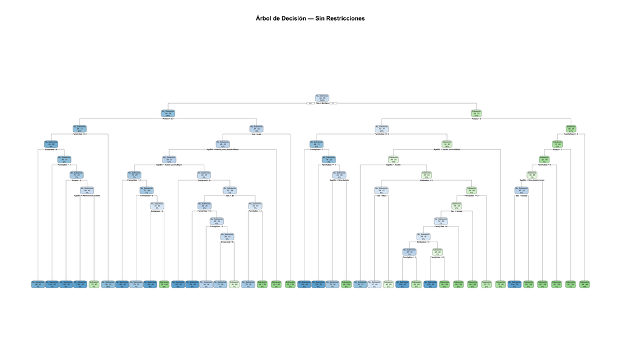

```r
rpart.plot(
  modelo_base,
  type          = 2,
  extra         = 104,
  fallen.leaves = TRUE,
  main          = "Árbol de Decisión — Sin Restricciones"
)
```

> Observá la profundidad y cantidad de nodos. Este árbol probablemente está memorizando los datos de entrenamiento.

## Evaluación del modelo base

```r
pred_base <- predict(modelo_base, newdata = test_data, type = "class")

cm_base <- confusionMatrix(
  data      = pred_base,
  reference = test_data$Survived,
  positive  = "Sobrevivio"
)

print(cm_base)
```

```
## Confusion Matrix and Statistics
##
##                Reference
## Prediction      No_Sobrevivio Sobrevivio
##   No_Sobrevivio           128         29
##   Sobrevivio                9         56
##
##                Accuracy : 0.8288
##                  95% CI : (0.7727, 0.8759)
##     No Information Rate : 0.6171
##     P-Value [Acc > NIR] : 5.476e-12
##
##                   Kappa : 0.6209
##
##  Mcnemar's Test P-Value : 0.002055
##
##             Sensitivity : 0.6588
##             Specificity : 0.9343
##          Pos Pred Value : 0.8615
##          Neg Pred Value : 0.8153
##              Prevalence : 0.3829
##          Detection Rate : 0.2523
##    Detection Prevalence : 0.2928
##       Balanced Accuracy : 0.7966
##
##        'Positive' Class : Sobrevivio
##
```

```r
acc_base <- cm_base$overall["Accuracy"]
cat("Exactitud del modelo base en prueba:", round(acc_base * 100, 2), "%\n")
```

```
## Exactitud del modelo base en prueba: 82.88 %
```

# Overfitting: Evidencia

```r
# Predicción sobre los datos de ENTRENAMIENTO.
pred_train_base <- predict(modelo_base, newdata = train_data, type = "class")
acc_train_base  <- mean(pred_train_base == train_data$Survived)

acc_test_base <- cm_base$overall["Accuracy"]

cat("Exactitud en ENTRENAMIENTO:", round(acc_train_base * 100, 2), "%\n")
```

```
## Exactitud en ENTRENAMIENTO: 86.7 %
```

```r
cat("Exactitud en PRUEBA:       ", round(acc_test_base  * 100, 2), "%\n")
```

```
## Exactitud en PRUEBA:        82.88 %
```

```r
cat("Diferencia:                ",
    round((acc_train_base - acc_test_base) * 100, 2), "puntos porcentuales\n")
```

```
## Diferencia:                 3.81 puntos porcentuales
```

> Si la exactitud en entrenamiento es mucho mayor que en prueba, el modelo memorizó en lugar de aprender patrones generales.

# Ajuste de Hiperparámetros — Árbol (Tuning)

## ¿Qué es `cp` (Complexity Parameter)?

`cp` penaliza la complejidad del árbol: si agregar una división no mejora el modelo al menos en `cp`, la división no se realiza.

- `cp` alto → árbol pequeño (puede subajustar).
- `cp` bajo → árbol grande (puede sobreajustar).

## Configuración de la validación cruzada

```r
# repeatedcv: repetir la validación cruzada varias veces para estimaciones
# más estables. number = 10 folds, repeats = 3 repeticiones.
# summaryFunction = twoClassSummary habilita ROC como métrica.
control_cv <- trainControl(
  method          = "repeatedcv",
  number          = 10,
  repeats         = 3,
  savePredictions = "final",
  classProbs      = TRUE,
  summaryFunction = twoClassSummary
)
```

## Grilla de búsqueda

```r
grilla_cp <- expand.grid(
  cp = c(0.001, 0.005, 0.01, 0.02, 0.05, 0.1)
)

print(grilla_cp)
```

```
##      cp
## 1 0.001
## 2 0.005
## 3 0.010
## 4 0.020
## 5 0.050
## 6 0.100
```

## Entrenamiento con tuning

```r
set.seed(42)

modelo_tuned <- train(
  Survived ~ .,
  data      = train_data,
  method    = "rpart",
  metric    = "ROC",
  trControl = control_cv,
  tuneGrid  = grilla_cp
)

print(modelo_tuned)
```

```
## CART
##
## 669 samples
##   7 predictor
##   2 classes: 'No_Sobrevivio', 'Sobrevivio'
##
## No pre-processing
## Resampling: Cross-Validated (10 fold, repeated 3 times)
## Summary of sample sizes: 603, 602, 603, 602, 601, 603, ...
## Resampling results across tuning parameters:
##
##   cp     ROC        Sens       Spec
##   0.001  0.8455508  0.9064266  0.6439487
##   0.005  0.8360684  0.9120596  0.6647692
##   0.010  0.8358361  0.8983546  0.7050769
##   0.020  0.8212825  0.8902826  0.7026154
##   0.050  0.7907525  0.8410569  0.7234872
##   0.100  0.7686650  0.7916376  0.7456923
##
## ROC was used to select the optimal model using the largest value.
## The final value used for the model was cp = 0.001.
```

## Visualización del tuning

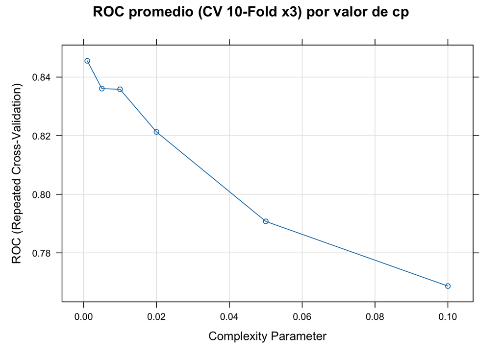

```r
plot(
  modelo_tuned,
  main = "ROC promedio (CV 10-Fold x3) por valor de cp"
)
```

```r
cat("Mejor valor de cp encontrado:", modelo_tuned$bestTune$cp, "\n")
```

```
## Mejor valor de cp encontrado: 0.001
```

## Árbol final

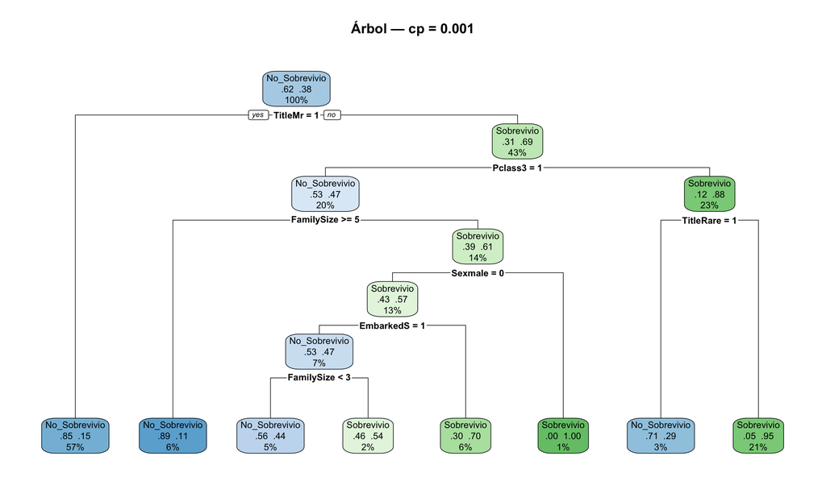

```r
rpart.plot(
  modelo_tuned$finalModel,
  type          = 2,
  extra         = 104,
  fallen.leaves = TRUE,
  main          = paste("Árbol — cp =", modelo_tuned$bestTune$cp)
)
```

## Evaluación

```r
pred_tuned <- predict(modelo_tuned, newdata = test_data, type = "raw")

cm_tuned <- confusionMatrix(
  data      = pred_tuned,
  reference = test_data$Survived,
  positive  = "Sobrevivio"
)

print(cm_tuned)
```

```
## Confusion Matrix and Statistics
##
##                Reference
## Prediction      No_Sobrevivio Sobrevivio
##   No_Sobrevivio           130         32
##   Sobrevivio                7         53
##
##                Accuracy : 0.8243
##                  95% CI : (0.7678, 0.872)
##     No Information Rate : 0.6171
##     P-Value [Acc > NIR] : 1.628e-11
##
##                   Kappa : 0.6063
##
##  Mcnemar's Test P-Value : 0.0001215
##
##             Sensitivity : 0.6235
##             Specificity : 0.9489
##          Pos Pred Value : 0.8833
##          Neg Pred Value : 0.8025
##              Prevalence : 0.3829
##          Detection Rate : 0.2387
##    Detection Prevalence : 0.2703
##       Balanced Accuracy : 0.7862
##
##        'Positive' Class : Sobrevivio
##
```

# Random Forest

Un árbol de decisión individual tiene un problema estructural: es muy sensible a los datos de entrenamiento. Pequeños cambios en los datos pueden producir un árbol completamente distinto.

**Random Forest** resuelve esto construyendo **muchos árboles en paralelo** y combinando sus predicciones por votación mayoritaria. Cada árbol se entrena con una muestra aleatoria de los datos y una selección aleatoria de variables — de ahí el nombre “bosque aleatorio”.

## ¿Por qué mejora al árbol individual?

- **Varianza reducida:** el promedio de muchos árboles es más estable que uno solo.
- **Menos overfitting:** la aleatoriedad evita que todos los árboles memoricen los mismos patrones.
- **Mejor generalización:** combina la “sabiduría” de múltiples perspectivas del problema.

## Hiperparámetros de `ranger`

Usamos `ranger`, una implementación de Random Forest con más control sobre el proceso de entrenamiento:

Hiperparámetros del Random Forest (ranger)

| Hiperparámetro | Descripción | Efecto |
| --- | --- | --- |
| mtry | Número de variables candidatas en cada división | Controla la diversidad entre árboles |
| min.node.size | Tamaño mínimo de un nodo hoja | Controla el tamaño del árbol (similar a min_samples_leaf) |
| splitrule | Criterio de división: ‘gini’ o ‘extratrees’ | extratrees añade aleatoriedad extra al punto de corte |

## Grilla de búsqueda

```r
# Con 7 variables, mtry típico es sqrt(7) ≈ 2-3.
# Explorar desde 2 hasta 6 para cubrir el espacio completo.
grilla_rf <- expand.grid(
  mtry          = c(2, 3, 4, 5, 6),
  min.node.size = c(1, 5, 10),
  splitrule     = c("gini", "extratrees")
)

cat("Combinaciones a evaluar:", nrow(grilla_rf), "\n")
```

```
## Combinaciones a evaluar: 30
```

## Entrenamiento con tuning

```r
set.seed(42)

modelo_rf <- train(
  Survived ~ .,
  data      = train_data,
  method    = "ranger",     # Random Forest con ranger
  metric    = "ROC",
  trControl = control_cv,   # Misma CV 10-Fold x3 definida anteriormente
  tuneGrid  = grilla_rf,
  num.trees = 500,          # 500 árboles en el bosque
  importance = "impurity"
)

print(modelo_rf)
```

```
## Random Forest
##
## 669 samples
##   7 predictor
##   2 classes: 'No_Sobrevivio', 'Sobrevivio'
##
## No pre-processing
## Resampling: Cross-Validated (10 fold, repeated 3 times)
## Summary of sample sizes: 603, 602, 603, 602, 601, 603, ...
## Resampling results across tuning parameters:
##
##   mtry  min.node.size  splitrule   ROC        Sens       Spec
##   2      1             gini        0.8431834  0.8911150  0.7184103
##   2      1             extratrees  0.8447646  0.8911537  0.6924615
##   2      5             gini        0.8443099  0.8895083  0.7184103
```

[output cut: 31 more lines]

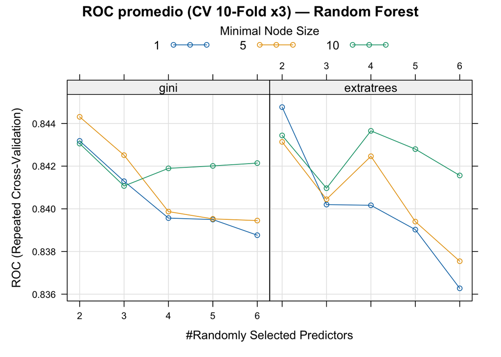

```r
plot(
  modelo_rf,
  main = "ROC promedio (CV 10-Fold x3) — Random Forest"
)
```

```r
cat("Mejor configuración encontrada:\n")
```

```
## Mejor configuración encontrada:
```

```r
print(modelo_rf$bestTune)
```

```
##   mtry  splitrule min.node.size
## 2    2 extratrees             1
```

## Importancia de variables

A diferencia del árbol individual, Random Forest no se puede dibujar como un diagrama. En cambio, reporta la **importancia de cada variable** como el promedio de su aporte en todos los 500 árboles.

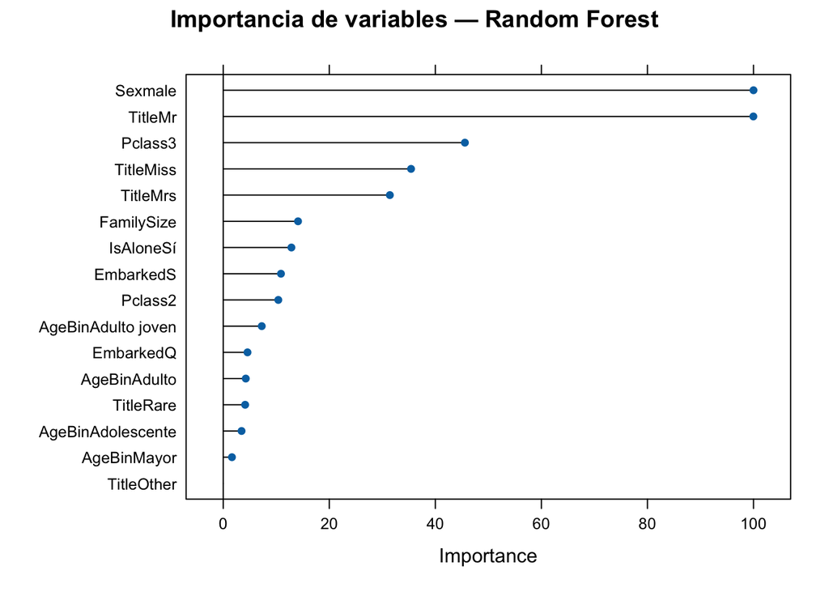

```r
importancia_rf <- varImp(modelo_rf)

plot(
  importancia_rf,
  main = "Importancia de variables — Random Forest"
)
```

## Evaluación

```r
pred_rf <- predict(modelo_rf, newdata = test_data, type = "raw")

cm_rf <- confusionMatrix(
  data      = pred_rf,
  reference = test_data$Survived,
  positive  = "Sobrevivio"
)

print(cm_rf)
```

```
## Confusion Matrix and Statistics
##
##                Reference
## Prediction      No_Sobrevivio Sobrevivio
##   No_Sobrevivio           126         28
##   Sobrevivio               11         57
##
##                Accuracy : 0.8243
##                  95% CI : (0.7678, 0.872)
##     No Information Rate : 0.6171
##     P-Value [Acc > NIR] : 1.628e-11
##
##                   Kappa : 0.6136
##
##  Mcnemar's Test P-Value : 0.01041
##
##             Sensitivity : 0.6706
##             Specificity : 0.9197
##          Pos Pred Value : 0.8382
##          Neg Pred Value : 0.8182
##              Prevalence : 0.3829
##          Detection Rate : 0.2568
##    Detection Prevalence : 0.3063
##       Balanced Accuracy : 0.7951
##
##        'Positive' Class : Sobrevivio
##
```

# Comparación Final de Modelos

```r
comparacion_final <- data.frame(
  Modelo = c(
    "Árbol — Sin Restricciones",
    "Árbol — Con Tuning",
    "Random Forest — Con Tuning"
  ),
  Exactitud = c(
    round(cm_base$overall["Accuracy"] * 100, 2),
    round(cm_tuned$overall["Accuracy"] * 100, 2),
    round(cm_rf$overall["Accuracy"] * 100, 2)
  ),
  Sensibilidad = c(
    round(cm_base$byClass["Sensitivity"] * 100, 2),
    round(cm_tuned$byClass["Sensitivity"] * 100, 2),
    round(cm_rf$byClass["Sensitivity"] * 100, 2)
  ),
  Especificidad = c(
    round(cm_base$byClass["Specificity"] * 100, 2),
    round(cm_tuned$byClass["Specificity"] * 100, 2),
    round(cm_rf$byClass["Specificity"] * 100, 2)
  ),
  Kappa = c(
    round(cm_base$overall["Kappa"], 4),
    round(cm_tuned$overall["Kappa"], 4),
    round(cm_rf$overall["Kappa"], 4)
  )
)

knitr::kable(
  comparacion_final,
  caption = "Comparación final de los tres modelos"
)
```

Comparación final de los tres modelos

| Modelo | Exactitud | Sensibilidad | Especificidad | Kappa |
| --- | --- | --- | --- | --- |
| Árbol — Sin Restricciones | 82.88 | 65.88 | 93.43 | 0.6209 |
| Árbol — Con Tuning | 82.43 | 62.35 | 94.89 | 0.6063 |
| Random Forest — Con Tuning | 82.43 | 67.06 | 91.97 | 0.6136 |

> - **Exactitud:** % de predicciones correctas en total.
> - **Sensibilidad:** % de sobrevivientes reales correctamente detectados.
> - **Especificidad:** % de no-sobrevivientes reales correctamente identificados.
> - **Kappa:** acuerdo entre predicción y realidad ajustado por azar (0 = azar, 1 = perfecto).

# Conclusiones